# Презентация по индивидуальной проекте: Этап 2

Основы информационной безопасности

Нджову Н.

Российский университет дружбы народов, Москва, Россия

18 марта 2025

## Цель работы

Приобретение практических навыков по установке DVWA.

## Задание

1. Установите DVWA на дистрибутив Kali Linux

## Выполнение лабораторной работы

Поскольку я буду настраивать DVWA на моем локальном хостинге, я откываю терминал и перехожу в каталог /var/www/html. Затем я клонирую репозиторий DVWA на github в каталог /html, используя команду git clone(рис.1).

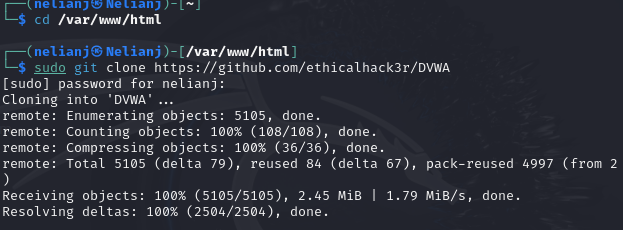

Клонирование репозитория

## Выполнение лабораторной работы

После этого, я запускаю команду ls, чтобы подвердить, что DVWA был успешно клонирован. После подверждения я меняю права доступа к файла DVWA(рис.2)

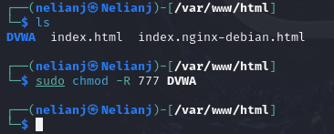

Изменение прав доступа

## Выполнение лабораторной работы

Чтобы настроить DVWA, нужно перейти в каталог /dvwa/config, затем проверяю содержимое каталога(рис.3)

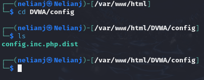

Перемещение по директориям

## Выполнение лабораторной работы

[figure not shown]

## Выполнение лабораторной работы

Теперь я открываю файл config.inc.php с помощью редактора nano, чтобы выполнить необходимые настройки(рис.5)

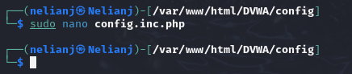

Открытие файла в редакторе

## Выполнение лабораторной работы

Я изменяю данные об имени пользователя и пароле(рис.6)

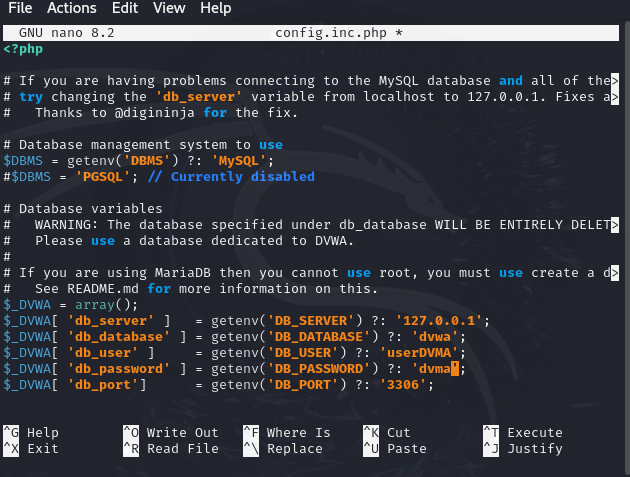

Редактирование файл

## Выполнение лабораторной работы

По умолчанию Kali Linux поставляется с установленным Система управления реляционными базами данных MariaDB. Поэтому мне не нужно устанавливать никаких пакетов, я просто запускаю службу mysql командой sudo systemctl start mysql(рис.7)

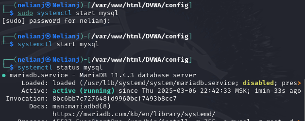

Запуск mysql

## Выполнение лабораторной работы

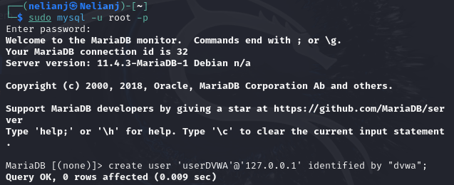

Авторизация в базе данных

## Выполнение лабораторной работы

Теперь я предоставляю этому пользователю полные привилегии над базой данных dvwa(рис.9)

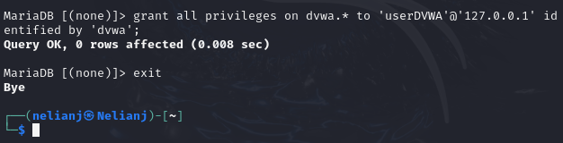

Изменение прав

## Выполнение лабораторной работы

В моем текущем каталоге я открываю файл php.ini с помощью текстового редактора(nano), чтобы редактировать его(рис.11)

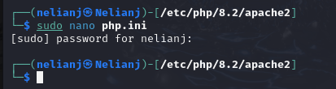

Открытие файла в текстовом редакторе

## Выполнение лабораторной работы

Я прокручиваю страницу вниз, ищу строки allow_url_fopen и allow_url_include и убеждаюсь, что обе они включены(рис.12)

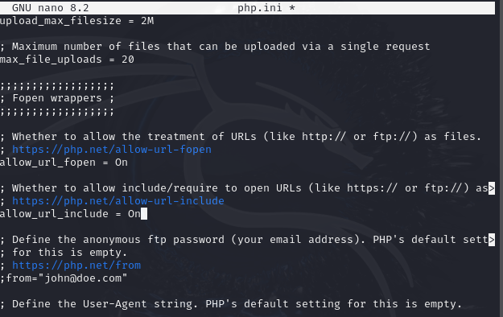

Редактирование файла

## Выполнение лабораторной работы

Я запускаю службу веб-сервера apache и проверяю, запущена ли служба (рис.13)

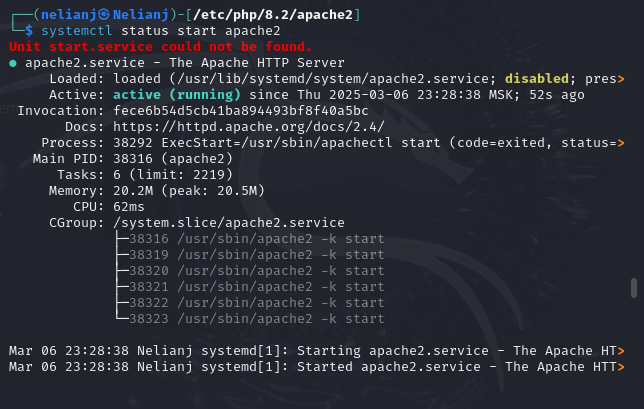

Запуск apche

## Выполнение лабораторной работы

Я настроила DVWA, Apache и базу данных, поэтому открываю браузер и запускаю веб-приложение, введя 127.0.0/DVWA(рис.14)

[figure not shown]

Запуск веб-приложения

## Выполнение лабораторной работы

Я прокручиваю страницу вниз и нажимаю на кнопку create reset database(рис.15)

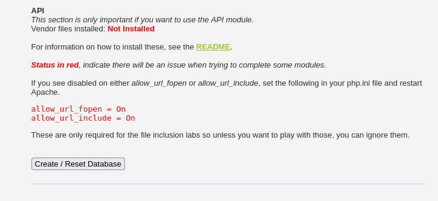

Создание базы данных

## Выполнение лабораторной работы

Я авторизуюсь с помощью предложенных по умолчанию данных(рис.16)

[figure not shown]

Авторизация

## Выполнение лабораторной работы

Я оказываюсь на домшней странице веб-приложения, на этом установка окончена(рис.17)

[figure not shown]

Домашняя страница DVWA

## Выводы

Выполнив эту работе, я приобрела практических навыков по установке уязвимого веб-приложения DVWA.